# Student Impact on Performance Analysis

```python
import pandas as pd
import matplotlib.pyplot as plt
import seaborn as sns
import numpy as np
sns.set_style('darkgrid')
```

## Reading the file

```python
data = pd.read_excel('D:/Data Science/07July2023/Questionaire_Data.xlsx', sheet_name = 'Processed Data')
```

```python
data.head(5)
```

|  | Datetime | Name | Email | College Name | Address | Family Type | Fathers Education | Mothers Education | Family Income_monthly | Academic Level | ... | Online Learning Continuation | Quick Response | Electronic gadget | Online Interactive Sessions | Missing Pratical Knowledge | Concentration lack | Online Lecture Useful | Online Environment Preferred | College Environment Preferred | Future Preferred Learning Mode |
| --- | --- | --- | --- | --- | --- | --- | --- | --- | --- | --- | --- | --- | --- | --- | --- | --- | --- | --- | --- | --- | --- |
| 0 | 2022/03/15 10:13:25 PM GMT+5:30 | Anuradha Dattatray kale | anuradhakatke@gmail.com | Vishwabharati Mahavidyalaya Cidco, Nanded | Urban | Joint | other | other | Below 10k | Undergraduate | ... | Yes | Yes | No | Yes | Yes | Yes | Yes | Yes | No | Online |
| 1 | 2022/03/25 4:35:35 PM GMT+5:30 | Ajay kumar | ajaywaghmare878877081@gimel. com | Vishwabharati Mahavidyalaya Cidco, Nanded | Urban | Nuclear | other | other | 15-25k | Research | ... | Yes | Yes | No | No | Yes | Yes | Yes | No | No | Online |
| 2 | 2022/03/15 5:09:20 PM GMT+5:30 | ASHISH BHIMARV | 9172358840 | AH6987 | Urban | Nuclear | Graduate | Graduate | Below 10k | Undergraduate | ... | No | Yes | Yes | No | Yes | No | Yes | Yes | Yes | Online |
| 3 | 2022/03/15 4:58:02 PM GMT+5:30 | Sunita Govind Dhakne | Sunitadhakne4@gmaiil.com | Punyashlok Ahilyadevi Holkar Solapur Universit... | Rural | Nuclear | other | other | Below 10k | Research | ... | Yes | Yes | Yes | Yes | Yes | Yes | Yes | Yes | Yes | Online |
| 4 | 2022/03/23 4:10:49 PM GMT+5:30 | Bhosle Sonaji Radhakishan | sonubhosle331@gmail.coom | School of Computational Sciences SRTMU Univers... | Urban | Joint | other | other | Below 10k | Post Graduate | ... | Yes | Yes | Yes | Yes | Yes | Yes | Yes | Yes | No | Online |

5 rows × 47 columns

## Basic Information of Data

```python
data.info()
```

```
<class 'pandas.core.frame.DataFrame'>
RangeIndex: 344 entries, 0 to 343
Data columns (total 47 columns):
 #   Column                          Non-Null Count  Dtype
---  ------                          --------------  -----
 0   Datetime                        344 non-null    object
 1   Name                            344 non-null    object
 2   Email                           344 non-null    object
 3   College Name                    344 non-null    object
 4   Address                         344 non-null    object
 5   Family Type                     344 non-null    object
 6   Fathers Education               344 non-null    object
 7   Mothers Education               344 non-null    object
 8   Family Income_monthly           344 non-null    object
 9   Academic Level                  344 non-null    object
```

[output cut: 39 more lines]

## Checking Duplicates

```python
data.duplicated().sum()
```

```
0
```

## Checking null values

```python
data.isnull().sum()
```

[output not shown]

## Unique Value in Columns

```python
print(data['College Name'].value_counts())
print(data['Family Income_monthly'].value_counts())
print(data['Academic Level'].value_counts())
print(data['Online Attendance Before Covid'].value_counts())
print(data['Learning Device'].value_counts())
print(data['Internet Type'].value_counts())
print(data['Weekly_40_hrs_study'].value_counts())
print(data['Home Internet Access'].value_counts())
print(data['No Offline Lectures'].value_counts())
print(data['Online Topic Clarification'].value_counts())
print(data['Unique Online Methods'].value_counts())
print(data['Avg Time Spend'].value_counts())
print(data['Online Methods Helpful'].value_counts())
print(data['Teachers Helpful Online'].value_counts())
print(data['Online Environment Preferred'].value_counts())
print(data['College Environment Preferred'].value_counts())
```

```
Vishwabharati Mahavidyalaya Cidco, Nanded                    96
KTHM College, Nashik                                         62
Swami Ramanand Teerth Marathwada University, Nanded          49
School of Computational Sciences SRTMU University Nanded     42
Laxmibai Deshmukh Mahila Mahavidyalaya                       36
Punyashlok Ahilyadevi Holkar Solapur University, Solapur     29
School of Mathematical Science, SRTMU Nanded                  8
GIVISH Amravati                                               5
Solapur University                                            4
Sangmeshwar college, Solapur                                  2
Dsm college jintur                                            2
AH6987                                                        1
School of communication                                       1
Mathematics                                                   1
School of Mathematics                                         1
School of mathematics and statistics                          1
SHAIKH HARUN MANSUR                                           1
Shri guru gobind sinhghji college of education nanded         1
Ushatai dhondage college                                      1
ZH6987                                                        1
Name: College Name, dtype: int64
Below 10k        161
More than 25k     69
10-15k            67
15-25k            47
Name: Family Income_monthly, dtype: int64
Post Graduate    187
Undergraduate    121
Junior            30
Research           6
Name: Academic Level, dtype: int64
Yes    196
No     148
Name: Online Attendance Before Covid, dtype: int64
Smartphone                          298
Laptop;Smartphone                    29
Laptop                                8
Desktop                               2
Desktop;Smartphone                    2
Laptop;Desktop;Smartphone             1
```

[output cut: 33 more lines]

```
Somewhat disagree     49
Strongly disagree     43
Name: Online Methods Helpful, dtype: int64
Very helpful          154
Slightly helpful       65
Moderately helpful     52
Extremely helpful      38
Not at all             35
Name: Teachers Helpful Online, dtype: int64
No     198
Yes    146
Name: Online Environment Preferred, dtype: int64
Yes    263
No      81
Name: College Environment Preferred, dtype: int64
```

# Exploratory Data Analysis

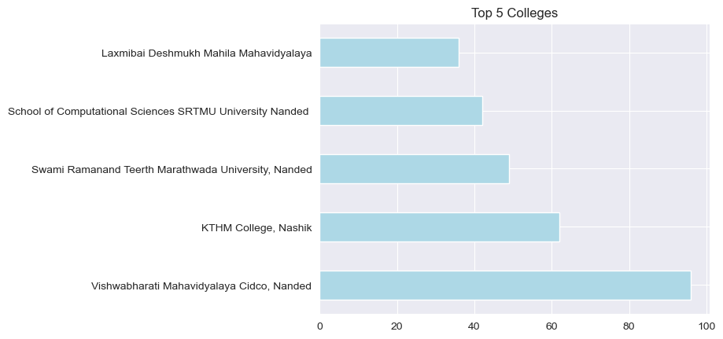

```python
data['College Name'].value_counts().head(5).plot(kind='barh',title='Top 5 Colleges',color='lightblue')
```

## Top 5 colleges where student have enrolled

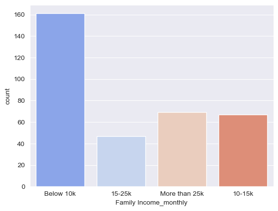

```python
sns.countplot(x='Family Income_monthly', data = data, palette='coolwarm')
```

## Family Monthly Income

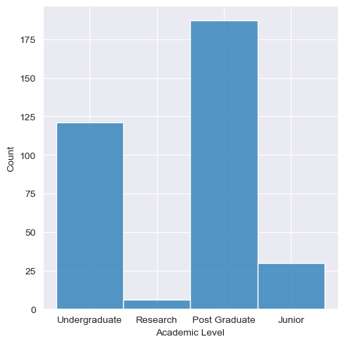

```python
sns.displot(x='Academic Level',data=data)
```

## Academic Level of Students

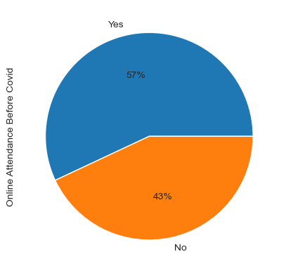

```python
data['Online Attendance Before Covid'].value_counts().plot(kind='pie',autopct='%0.0f%%')
```

## Online Attendance before Covid is 57%

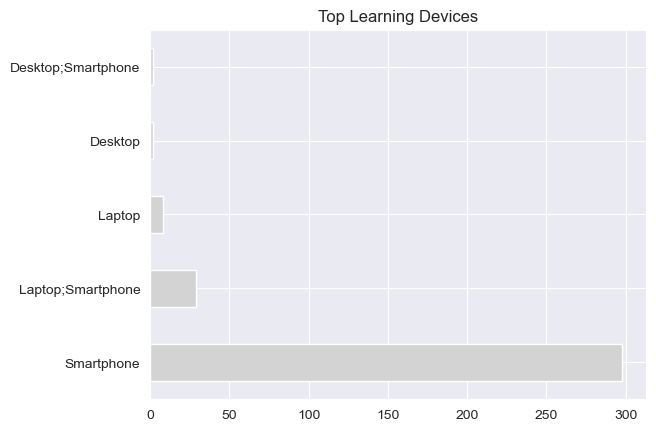

```python
data['Learning Device'].value_counts().head().plot(kind='barh',title='Top Learning Devices',color='lightgrey')
```

## This clearly shows that smartphone is most likely used by students

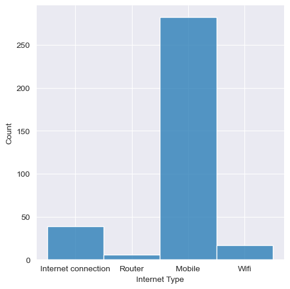

```python
sns.displot(x='Internet Type',data=data)
```

## This shows that mobile internet is mostly used by student.

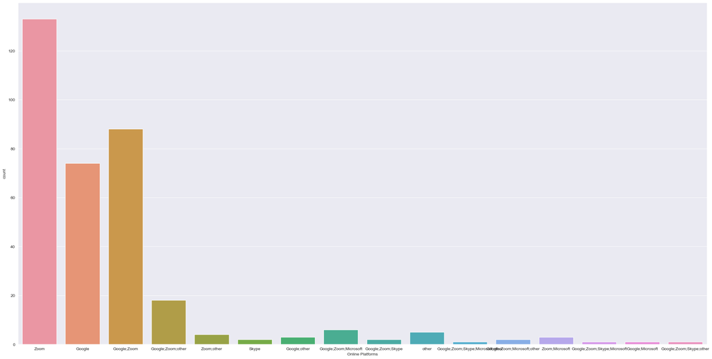

```python
plt.figure(figsize=(30,15))
sns.countplot(x='Online Platforms',data=data)
```

## This shows that Zoom is mostly used online platform by the students

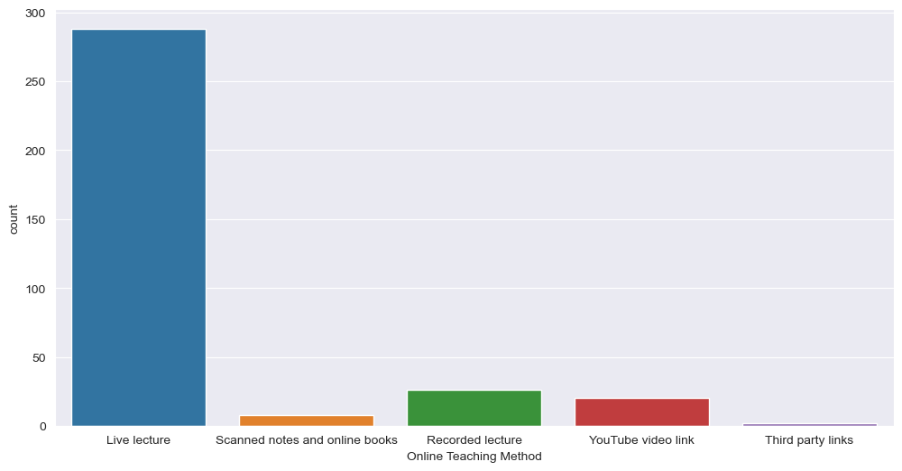

```python
plt.figure(figsize=(12,8))
sns.countplot(x='Online Teaching Method',data=data)
```

## Online Teaching method preferred is Live Lecture

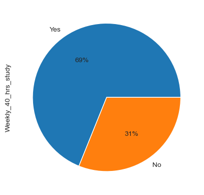

```python
data['Weekly_40_hrs_study'].value_counts().plot(kind='pie',autopct='%0.0f%%')
```

## 69% of students are dedicating for weekly 40 hrs study

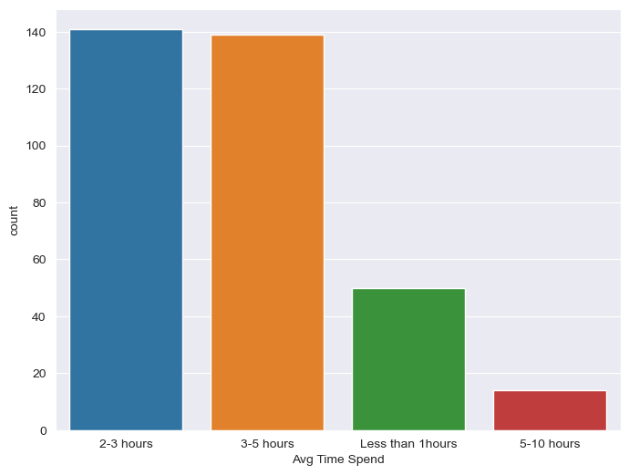

```python
plt.figure(figsize=(8,6))
sns.countplot(x='Avg Time Spend',data=data)
```

## Avg time spend by students are either 2-3 hrs or 3-5 hrs

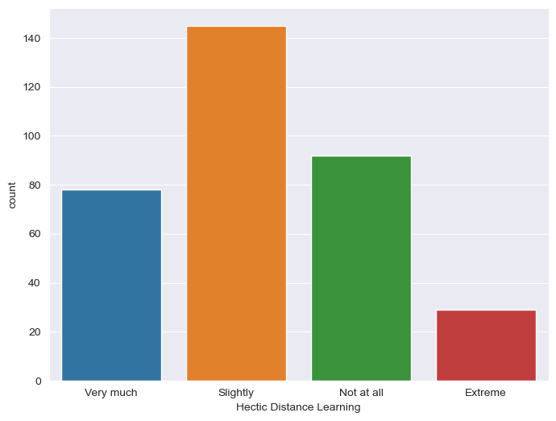

```python
plt.figure(figsize=(8,6))
sns.countplot(x='Hectic Distance Learning',data=data)
```

## More then 140 students says its slightly hectic distance learning

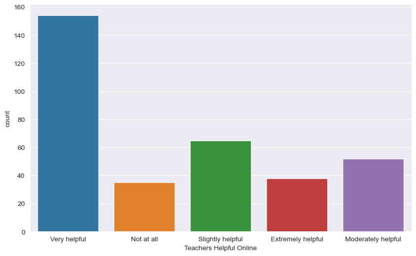

```python
plt.figure(figsize=(10,6))
sns.countplot(x='Teachers Helpful Online',data=data)
```

## More then 150 students says teachers are helpful online

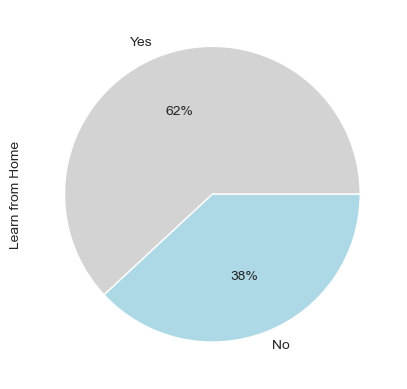

```python
data['Learn from Home'].value_counts().plot(kind='pie',autopct='%0.0f%%',colors=['Lightgrey','LightBlue'])
```

## 62% of students wants to learn from home

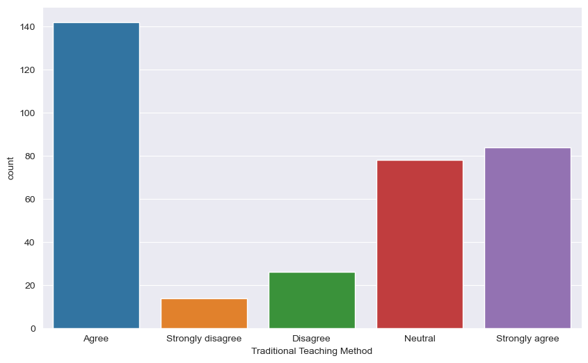

```python
plt.figure(figsize=(10,6))
sns.countplot(x='Traditional Teaching Method',data=data)
```

## More then 140 students agree with Traditional teaching method

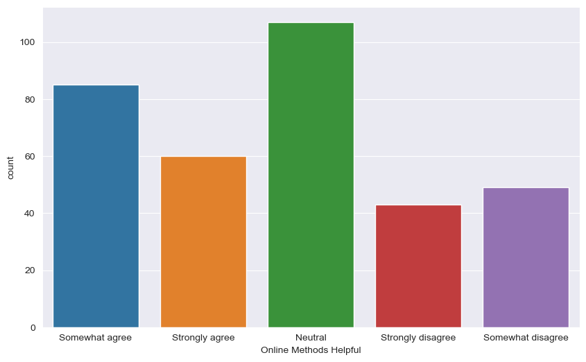

```python
plt.figure(figsize=(10,6))
sns.countplot(x='Online Methods Helpful',data=data)
```

## More then 80 students agree with Online method and 100+ are neutral

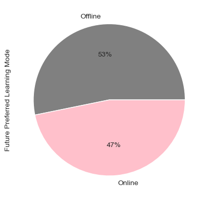

```python
data['Future Preferred Learning Mode'].value_counts().plot(kind='pie',autopct='%0.0f%%',colors=['grey','pink'])
```

## 53% of stdents says offline learning method for future

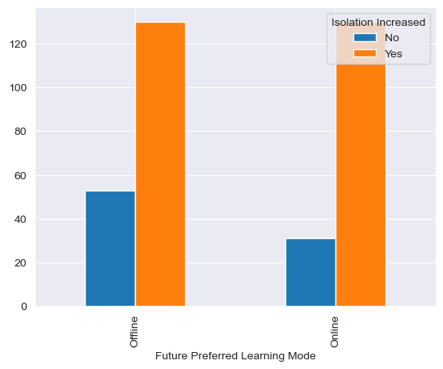

```python
plt.figure(figsize=(10,20))
pd.crosstab(data['Future Preferred Learning Mode'],data['Isolation Increased']).plot(kind='bar')
```

## More the 120 students says yes isolation increases be it offline/online

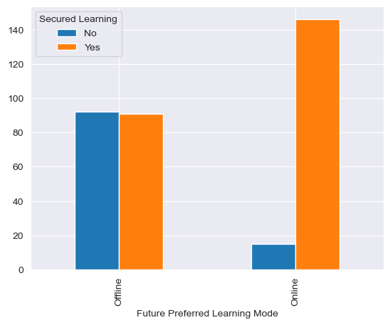

```python
pd.crosstab(data['Future Preferred Learning Mode'],data['Secured Learning']).plot(kind='bar')
```

## More then 140 students says online gives secured learning

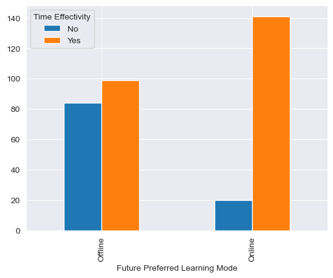

```python
pd.crosstab(data['Future Preferred Learning Mode'],data['Time Effectivity']).plot(kind='bar')
```

## More then 140 students agrees online learning mode is time effective

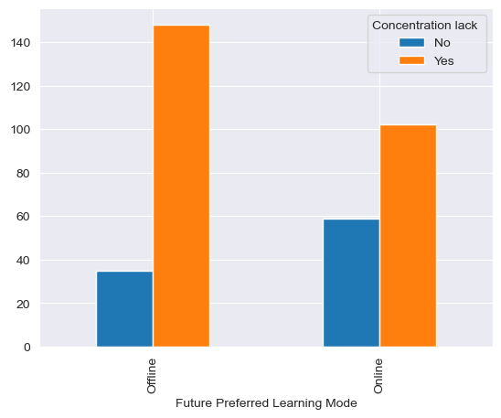

```python
pd.crosstab(data['Future Preferred Learning Mode'],data['Concentration lack ']).plot(kind='bar')
```

## with Offline more then 140 students say yes the concentration lacks

## with online 100+ students say yes for conentartion lacks

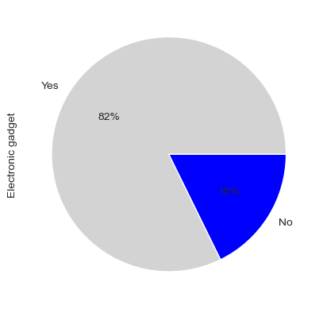

```python
data['Electronic gadget'].value_counts().plot(kind='pie',autopct='%0.0f%%',colors=['lightgrey','blue'])
```

## 82% of students agrees that electronic gadget improved technical skills in online learning methods

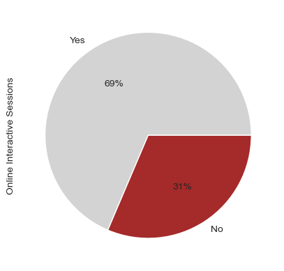

```python
data['Online Interactive Sessions'].value_counts().plot(kind='pie',autopct='%0.0f%%',colors=['lightgrey','brown'])
```

## 69% of students agrees for Online Interactive Sessions

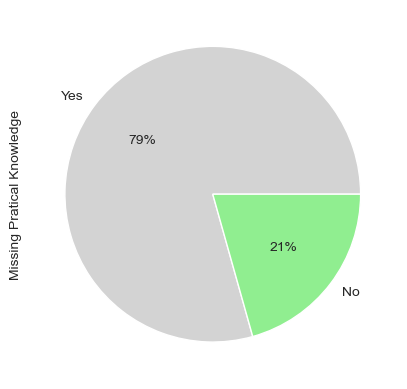

```python
data['Missing Pratical Knowledge'].value_counts().plot(kind='pie',autopct='%0.0f%%',colors=['lightgrey','lightgreen'])
```

## 79% of students says they are missing practical knowledge due to online classes

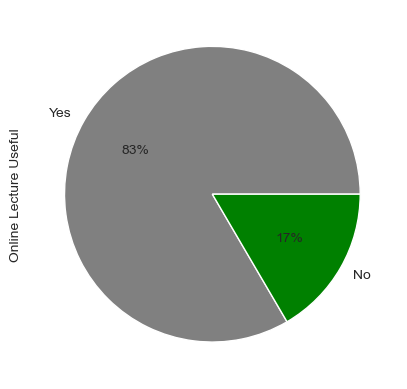

```python
data['Online Lecture Useful'].value_counts().plot(kind='pie',autopct='%0.0f%%',colors=['grey','green'])
```

## 83% of students agrees with online lectures are useful

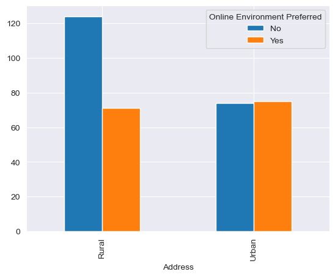

```python
pd.crosstab(data['Address'],data['Online Environment Preferred']).plot(kind='bar')
```

## More then 120 students fom rural areas says no to online preferrence where as in urban we see mixed reactions

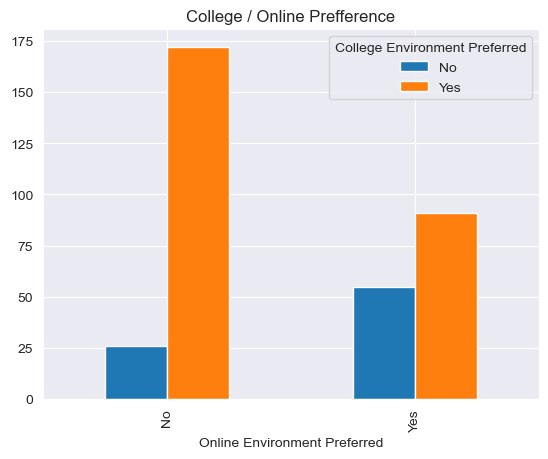

```python
pd.crosstab(data['Online Environment Preferred'],data['College Environment Preferred']).plot(kind='bar',title='College / Online Prefference')
```

## The above graphs shows that college environment is most preffered then online.

# Conclusion

## 4) Students agrees that online lectures are more useful

## 5) The electronic gadgets helps in technical skills in online learning

## There is an negative impact as well in online learning

## 1) Some students like offline learning, Tradtional way of teaching

## 2) Missing on practical Knowlegdge

## 3) Face to Face Intercation missing

## 4) In rural areas still due to internet connectivity issues students preferred offline learning method.

## 5) College environment is preferred by the students rather the online environment.

# Applying Decision Tree Classification Method

```python
from sklearn.tree import DecisionTreeClassifier
from sklearn.metrics import confusion_matrix, ConfusionMatrixDisplay, classification_report, accuracy_score
from sklearn import tree
```

## Since all the data types are object we need to use label encoder to convert into numerical

```python
from sklearn.preprocessing import LabelEncoder
```

```python
le = LabelEncoder()
```

```python
data.columns
```

```
Index(['Datetime', 'Name', 'Email', 'College Name', 'Address', 'Family Type',
       'Fathers Education', 'Mothers Education', 'Family Income_monthly',
       'Academic Level', 'Online Attendance Before Covid', 'Learning Device',
       'Internet Type', 'Home Internet Access', 'Online Platforms',
       'Online Teaching Method', 'Comfortable Technology ', 'Internet Access',
       'Weekly_40_hrs_study', 'Avg Time Spend', 'Downloading Knowledge',
       'Self Motivated', 'Hours Spend', 'Email_WebBrowser', 'Teacher Meet',
       'No Offline Lectures', 'Online Topic Clarification',
       'Unique Online Methods', 'Learn from Home', 'Hectic Distance Learning',
       'Teachers Helpful Online', 'Syallbus Coverage ',
       'Traditional Teaching Method', 'Online Methods Helpful',
       'Isolation Increased', 'Secured Learning', 'Time Effectivity',
       'Online Learning Continuation', 'Quick Response ', 'Electronic gadget',
       'Online Interactive Sessions', 'Missing Pratical Knowledge',
       'Concentration lack ', 'Online Lecture Useful',
       'Online Environment Preferred', 'College Environment Preferred',
       'Future Preferred Learning Mode'],
      dtype='object')
```

```python
data['Address'] = le.fit_transform(data['Address'])
data['Family Type'] = le.fit_transform(data['Family Type'])
data['Fathers Education'] = le.fit_transform(data['Fathers Education'])
data['Mothers Education'] = le.fit_transform(data['Mothers Education'])
data['Family Income_monthly'] = le.fit_transform(data['Family Income_monthly'])
data['Academic Level'] = le.fit_transform(data['Academic Level'])
data['Online Attendance Before Covid'] = le.fit_transform(data['Online Attendance Before Covid'])
data['Learning Device'] = le.fit_transform(data['Learning Device'])
data['Internet Type'] = le.fit_transform(data['Internet Type'])
data['Home Internet Access'] = le.fit_transform(data['Home Internet Access'])
data['Online Platforms'] = le.fit_transform(data['Online Platforms'])
data['Online Teaching Method'] = le.fit_transform(data['Online Teaching Method'])
data['Comfortable Technology '] = le.fit_transform(data['Comfortable Technology '])
data['Internet Access'] = le.fit_transform(data['Internet Access'])
data['Weekly_40_hrs_study'] = le.fit_transform(data['Weekly_40_hrs_study'])
data['Avg Time Spend'] = le.fit_transform(data['Avg Time Spend'])
data['Downloading Knowledge'] = le.fit_transform(data['Downloading Knowledge'])
data['Self Motivated'] = le.fit_transform(data['Self Motivated'])
data['Hours Spend'] = le.fit_transform(data['Hours Spend'])
data['Email_WebBrowser'] = le.fit_transform(data['Email_WebBrowser'])
data['Teacher Meet'] = le.fit_transform(data['Teacher Meet'])
data['No Offline Lectures'] = le.fit_transform(data['No Offline Lectures'])
data['Online Topic Clarification'] = le.fit_transform(data['Online Topic Clarification'])
data['Unique Online Methods'] = le.fit_transform(data['Unique Online Methods'])
data['Learn from Home'] = le.fit_transform(data['Learn from Home'])
data['Hectic Distance Learning'] = le.fit_transform(data['Hectic Distance Learning'])
data['Teachers Helpful Online'] = le.fit_transform(data['Teachers Helpful Online'])
data['Syallbus Coverage '] = le.fit_transform(data['Syallbus Coverage '])
data['Traditional Teaching Method'] = le.fit_transform(data['Traditional Teaching Method'])
data['Online Methods Helpful'] = le.fit_transform(data['Online Methods Helpful'])
data['Isolation Increased'] = le.fit_transform(data['Isolation Increased'])
data['Secured Learning'] = le.fit_transform(data['Secured Learning'])
data['Time Effectivity'] = le.fit_transform(data['Time Effectivity'])
data['Online Learning Continuation'] = le.fit_transform(data['Online Learning Continuation'])
data['Quick Response '] = le.fit_transform(data['Quick Response '])
data['Electronic gadget'] = le.fit_transform(data['Electronic gadget'])
data['Online Interactive Sessions'] = le.fit_transform(data['Online Interactive Sessions'])
data['Missing Pratical Knowledge'] = le.fit_transform(data['Missing Pratical Knowledge'])
data['Concentration lack '] = le.fit_transform(data['Concentration lack '])
data['Online Lecture Useful'] = le.fit_transform(data['Online Lecture Useful'])
data['Online Environment Preferred'] = le.fit_transform(data['Online Environment Preferred'])
data['College Environment Preferred'] = le.fit_transform(data['College Environment Preferred'])
```

```python
data.head(5)
```

|  | Datetime | Name | Email | College Name | Address | Family Type | Fathers Education | Mothers Education | Family Income_monthly | Academic Level | ... | Online Learning Continuation | Quick Response | Electronic gadget | Online Interactive Sessions | Missing Pratical Knowledge | Concentration lack | Online Lecture Useful | Online Environment Preferred | College Environment Preferred | Future Preferred Learning Mode |
| --- | --- | --- | --- | --- | --- | --- | --- | --- | --- | --- | --- | --- | --- | --- | --- | --- | --- | --- | --- | --- | --- |
| 0 | 2022/03/15 10:13:25 PM GMT+5:30 | Anuradha Dattatray kale | anuradhakatke@gmail.com | Vishwabharati Mahavidyalaya Cidco, Nanded | 1 | 0 | 2 | 2 | 2 | 3 | ... | 1 | 1 | 0 | 1 | 1 | 1 | 1 | 1 | 0 | Online |
| 1 | 2022/03/25 4:35:35 PM GMT+5:30 | Ajay kumar | ajaywaghmare878877081@gimel. com | Vishwabharati Mahavidyalaya Cidco, Nanded | 1 | 1 | 2 | 2 | 1 | 2 | ... | 1 | 1 | 0 | 0 | 1 | 1 | 1 | 0 | 0 | Online |
| 2 | 2022/03/15 5:09:20 PM GMT+5:30 | ASHISH BHIMARV | 9172358840 | AH6987 | 1 | 1 | 0 | 0 | 2 | 3 | ... | 0 | 1 | 1 | 0 | 1 | 0 | 1 | 1 | 1 | Online |
| 3 | 2022/03/15 4:58:02 PM GMT+5:30 | Sunita Govind Dhakne | Sunitadhakne4@gmaiil.com | Punyashlok Ahilyadevi Holkar Solapur Universit... | 0 | 1 | 2 | 2 | 2 | 2 | ... | 1 | 1 | 1 | 1 | 1 | 1 | 1 | 1 | 1 | Online |
| 4 | 2022/03/23 4:10:49 PM GMT+5:30 | Bhosle Sonaji Radhakishan | sonubhosle331@gmail.coom | School of Computational Sciences SRTMU Univers... | 1 | 0 | 2 | 2 | 2 | 1 | ... | 1 | 1 | 1 | 1 | 1 | 1 | 1 | 1 | 0 | Online |

5 rows × 47 columns

```python
x = data.iloc[:,4:46]
x
```

|  | Address | Family Type | Fathers Education | Mothers Education | Family Income_monthly | Academic Level | Online Attendance Before Covid | Learning Device | Internet Type | Home Internet Access | ... | Time Effectivity | Online Learning Continuation | Quick Response | Electronic gadget | Online Interactive Sessions | Missing Pratical Knowledge | Concentration lack | Online Lecture Useful | Online Environment Preferred | College Environment Preferred |
| --- | --- | --- | --- | --- | --- | --- | --- | --- | --- | --- | --- | --- | --- | --- | --- | --- | --- | --- | --- | --- | --- |
| 0 | 1 | 0 | 2 | 2 | 2 | 3 | 1 | 8 | 0 | 1 | ... | 1 | 1 | 1 | 0 | 1 | 1 | 1 | 1 | 1 | 0 |
| 1 | 1 | 1 | 2 | 2 | 1 | 2 | 1 | 8 | 2 | 0 | ... | 0 | 1 | 1 | 0 | 0 | 1 | 1 | 1 | 0 | 0 |
| 2 | 1 | 1 | 0 | 0 | 2 | 3 | 1 | 0 | 1 | 1 | ... | 0 | 0 | 1 | 1 | 0 | 1 | 0 | 1 | 1 | 1 |
| 3 | 0 | 1 | 2 | 2 | 2 | 2 | 1 | 8 | 1 | 1 | ... | 1 | 1 | 1 | 1 | 1 | 1 | 1 | 1 | 1 | 1 |
| 4 | 1 | 0 | 2 | 2 | 2 | 1 | 1 | 8 | 0 | 0 | ... | 1 | 1 | 1 | 1 | 1 | 1 | 1 | 1 | 1 | 0 |
| ... | ... | ... | ... | ... | ... | ... | ... | ... | ... | ... | ... | ... | ... | ... | ... | ... | ... | ... | ... | ... | ... |
| 339 | 0 | 0 | 1 | 2 | 2 | 1 | 1 | 3 | 1 | 1 | ... | 1 | 1 | 1 | 0 | 0 | 1 | 1 | 1 | 1 | 1 |
| 340 | 0 | 1 | 1 | 2 | 2 | 1 | 0 | 8 | 1 | 0 | ... | 1 | 0 | 1 | 1 | 1 | 1 | 1 | 1 | 0 | 1 |
| 341 | 1 | 1 | 3 | 1 | 1 | 3 | 1 | 8 | 1 | 1 | ... | 1 | 0 | 1 | 1 | 1 | 1 | 1 | 0 | 1 | 0 |
| 342 | 1 | 0 | 1 | 1 | 3 | 3 | 1 | 8 | 1 | 1 | ... | 1 | 1 | 1 | 1 | 1 | 1 | 1 | 1 | 1 | 1 |
| 343 | 1 | 0 | 1 | 1 | 2 | 3 | 1 | 0 | 1 | 1 | ... | 1 | 1 | 1 | 1 | 1 | 1 | 1 | 1 | 1 | 1 |

344 rows × 42 columns

```python
y = data['Future Preferred Learning Mode']
y
```

```
0       Online
1       Online
2       Online
3       Online
4       Online
        ...
339     Online
340    Offline
341    Offline
342     Online
343     Online
Name: Future Preferred Learning Mode, Length: 344, dtype: object
```

```python
model = DecisionTreeClassifier(criterion = 'gini')
clf = model.fit(x,y)
```

```python
pred = clf.predict(x)
pred
```

```
array(['Online', 'Online', 'Online', 'Online', 'Online', 'Offline',
       'Online', 'Offline', 'Offline', 'Offline', 'Offline', 'Offline',
       'Offline', 'Offline', 'Online', 'Offline', 'Online', 'Offline',
       'Offline', 'Offline', 'Offline', 'Offline', 'Online', 'Online',
       'Online', 'Offline', 'Offline', 'Offline', 'Offline', 'Online',
       'Online', 'Offline', 'Online', 'Offline', 'Offline', 'Offline',
       'Offline', 'Offline', 'Offline', 'Offline', 'Offline', 'Offline',
       'Offline', 'Offline', 'Offline', 'Offline', 'Online', 'Online',
       'Offline', 'Online', 'Offline', 'Offline', 'Offline', 'Offline',
       'Offline', 'Offline', 'Online', 'Offline', 'Online', 'Online',
       'Online', 'Offline', 'Offline', 'Offline', 'Online', 'Offline',
       'Online', 'Online', 'Offline', 'Online', 'Online', 'Offline',
       'Offline', 'Offline', 'Offline', 'Offline', 'Offline', 'Online',
       'Online', 'Online', 'Online', 'Offline', 'Offline', 'Offline',
       'Online', 'Offline', 'Offline', 'Online', 'Offline', 'Offline',
       'Online', 'Online', 'Offline', 'Offline', 'Online', 'Offline',
       'Offline', 'Online', 'Online', 'Offline', 'Offline', 'Offline',
       'Offline', 'Online', 'Offline', 'Offline', 'Offline', 'Offline',
       'Online', 'Online', 'Online', 'Offline', 'Offline', 'Online',
       'Offline', 'Online', 'Offline', 'Offline', 'Offline', 'Offline',
       'Online', 'Offline', 'Online', 'Offline', 'Offline', 'Offline',
       'Offline', 'Offline', 'Offline', 'Offline', 'Offline', 'Online',
       'Online', 'Offline', 'Online', 'Offline', 'Online', 'Online',
       'Offline', 'Offline', 'Online', 'Online', 'Offline', 'Offline',
       'Offline', 'Online', 'Online', 'Online', 'Online', 'Online',
       'Online', 'Online', 'Online', 'Online', 'Offline', 'Offline',
       'Offline', 'Online', 'Online', 'Online', 'Offline', 'Offline',
       'Online', 'Online', 'Online', 'Offline', 'Offline', 'Online',
       'Offline', 'Online', 'Offline', 'Offline', 'Online', 'Offline',
       'Offline', 'Online', 'Offline', 'Online', 'Online', 'Online',
       'Online', 'Online', 'Online', 'Offline', 'Offline', 'Online',
       'Online', 'Offline', 'Offline', 'Online', 'Offline', 'Offline',
       'Offline', 'Offline', 'Offline', 'Offline', 'Online', 'Online',
       'Offline', 'Offline', 'Online', 'Offline', 'Offline', 'Offline',
       'Online', 'Online', 'Offline', 'Offline', 'Offline', 'Offline',
       'Offline', 'Online', 'Offline', 'Offline', 'Offline', 'Online',
       'Offline', 'Online', 'Offline', 'Online', 'Offline', 'Offline',
       'Online', 'Offline', 'Online', 'Online', 'Online', 'Online',
       'Offline', 'Offline', 'Offline', 'Offline', 'Offline', 'Online',
       'Offline', 'Offline', 'Online', 'Online', 'Online', 'Online',
       'Offline', 'Offline', 'Offline', 'Offline', 'Online', 'Offline',
       'Online', 'Offline', 'Online', 'Online', 'Online', 'Online',
       'Online', 'Online', 'Offline', 'Online', 'Online', 'Offline',
       'Online', 'Online', 'Offline', 'Online', 'Online', 'Online',
       'Online', 'Online', 'Online', 'Offline', 'Offline', 'Offline',
       'Online', 'Offline', 'Online', 'Online', 'Offline', 'Online',
       'Online', 'Online', 'Online', 'Online', 'Offline', 'Online',
       'Online', 'Online', 'Online', 'Online', 'Online', 'Offline',
       'Online', 'Offline', 'Offline', 'Online', 'Online', 'Online',
       'Offline', 'Offline', 'Offline', 'Offline', 'Offline', 'Online',
       'Online', 'Offline', 'Online', 'Online', 'Online', 'Offline',
       'Online', 'Online', 'Online', 'Online', 'Online', 'Online',
       'Offline', 'Offline', 'Offline', 'Offline', 'Online', 'Offline',
       'Offline', 'Offline', 'Offline', 'Offline', 'Online', 'Offline',
       'Offline', 'Online', 'Online', 'Online', 'Offline', 'Offline',
       'Offline', 'Online', 'Online', 'Online', 'Offline', 'Online',
       'Online', 'Online', 'Online', 'Online', 'Offline', 'Offline',
       'Online', 'Online'], dtype=object)
```

```python
result = confusion_matrix(y,pred)
result
```

```
array([[183,   0],
       [  0, 161]], dtype=int64)
```

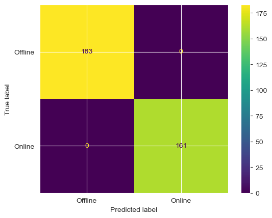

```python
ConfusionMatrixDisplay(result, display_labels=clf.classes_).plot()
plt.show()
```

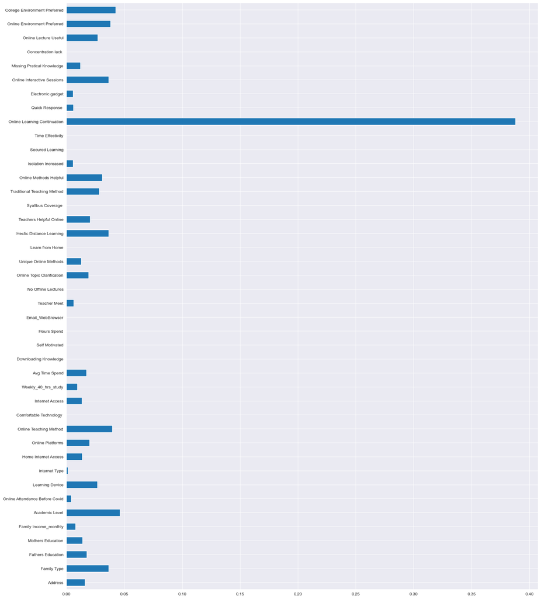

```python
plt.figure(figsize=(20,25))
feat_imp = pd.Series(clf.feature_importances_, index=x.columns)
feat_imp.plot(kind='barh')
```

```python
accuracy_score(y,pred)*100
```

```
100.0
```

[output not shown]

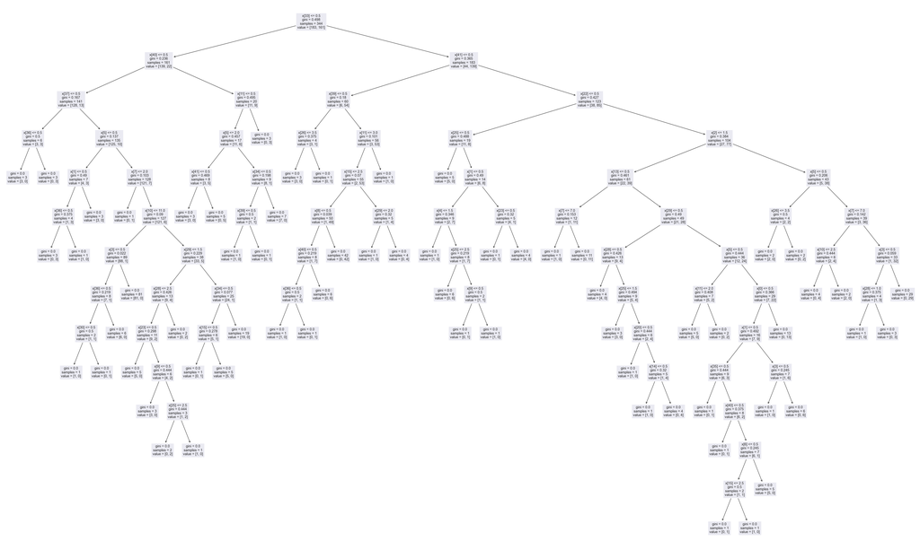

```python
plt.figure(figsize=(50,30))
tree.plot_tree(clf)
```

## The Model is Prediciting 100% accuracy